# Github Basics

Sam Olivares-Mejia and Laura Palacios

2022-11-18

## First Time Set Up

This section is adapted from Kate Miller and Sarah Wright’s IMD Training on [Version Control](https://katemmiller.github.io/IMD_R_Training_Advanced/)

### 1. Install Git

Git is the software needed for this learning session.If you do not already have Git installed on your computer, please install before the session.

1. Open the **Software Center** application on your computer (this will allow you to download without admin approval)
2. Navigate to the **Applications** tab
3. Click on **Git**
4. Click Install

[figure not shown]

If you’re having issues installing Git, consult the [R Advisory Group Resources Sharepoint site](https://doimspp.sharepoint.com/sites/nps-nrss-imdiv/SitePages/R-Adv.aspx) and submit a helpdesk ticket if needed.

### 2. Set Up a Github Account

Go to [Join Github](https://github.com/join) to get started!

Username example: LpalaciosNPS or sam-olivares-mejia

You will need to verify your email to complete the joining process.

Once verified you will see the screen below. You don’t need to personalize your account right away, click skip to reach your home screen.

[figure not shown]

Your new home page will look like this

[figure not shown]

**To Do: Once you’ve completed this step**  
**Please email your username to Sam (samantha_olivares-mejia@partner.nps.gov)** so she can add you to our training github page!

Still having trouble? This [Wiki How](https://www.wikihow.com/Create-an-Account-on-GitHub) gives in depth instructions.

### 3. Open R Studio and install the `usethis` package

Remember, to install packages we use the install.packages() function. You can type this in the Console.

[figure not shown]

### 4. Navigate to **Tools > Global Options**

1. On the list on the left, click on GIT SVN
2. Make sure the ’Enable version interface for RStudio project box is checked
3. Your screen should look like this (git.exe path may differ)

[figure not shown]

4. Click Apply then OK

### 5. Create a Personal Access Token

Your personal access token is used to connect your Github account to RStudio.

1. run the code below in R Studio which will open a web browser to create a personal access token

```r
# This opens up a browser window where you can create a personal access token. It may ask you to log into GitHub or confirm your password.
usethis::create_github_token()
```

2. once you’ve logged into GitHub your page will look like this

[figure not shown]

3. enter ‘RStudio’ in the ***Note** field
4. set the **expiration** to a later date (I’d reccommend a year)
5. scroll to the bottom and click **generate token**
6. this code will only generate once so make sure you **copy the personal access token to your clipboard**!!!

### 6. Insert your personal access token in the Git Credential Store

1. run the code below and when prompted paste your personal access token

```r
gitcreds::gitcreds_set()
```

## Github Overview

### Git vs. GitHub

Git/Github is a type of **version control** which is a way to save your progress in an organized manner. It allows you to keep track of your changes every step of the way, and allows for easy collaboration between teams.

Git and Github are used interchangeably, however they are two sperate entities.

**Git** is the software you install on your computer **GitHub** is an online interface for storing and collaborating with code.

### Some terminology

[figure not shown]

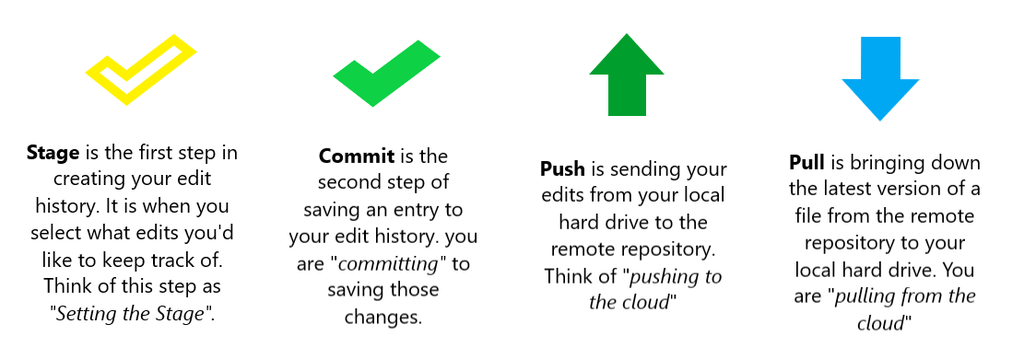

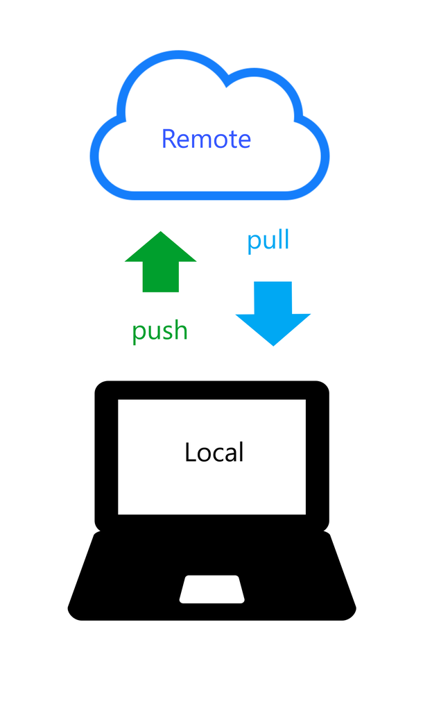

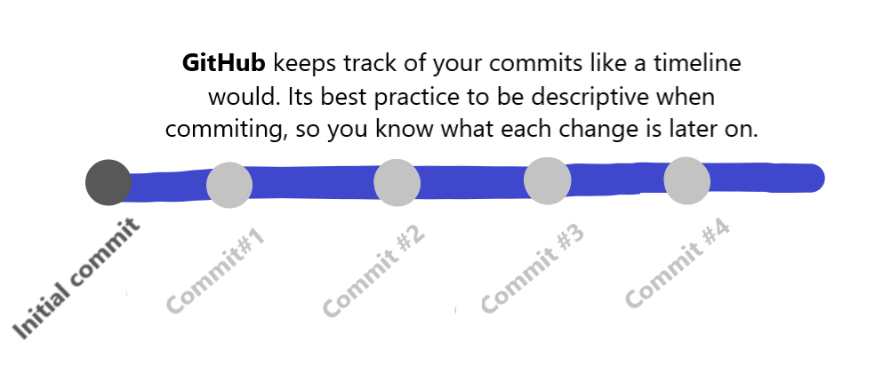

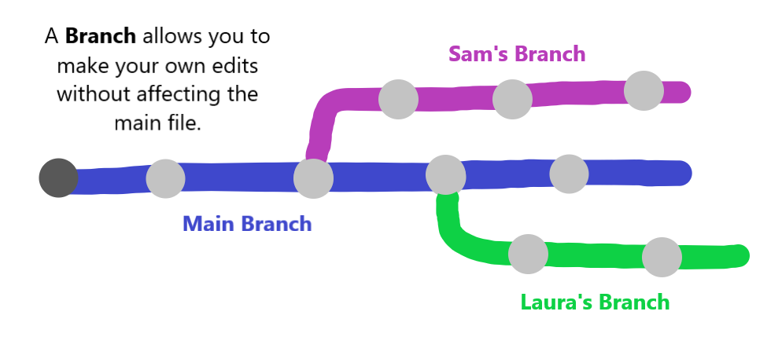

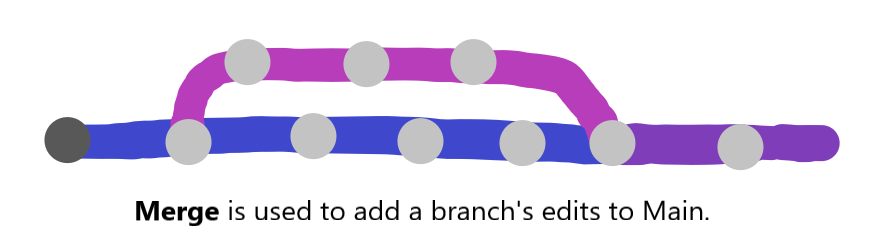

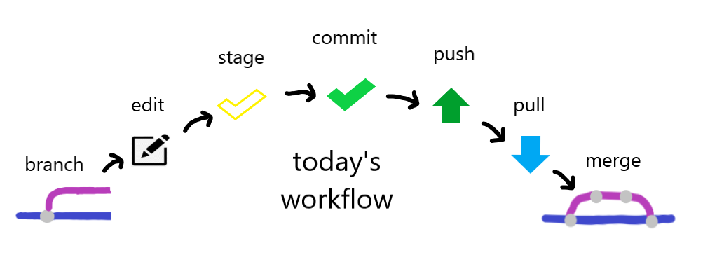

## Branch and Clone Repository

### Branch

First we are going to create a branch from main. To do this, go to the [SWNC Learning Github Repository](https://github.com/sam-olivares-mejia/SWNC_Learning_Github).

If you’ve emailed Sam your GitHub username you should have contributor access to the repository.

Click on the **main dropdown** in the upper left, and begin typing your name separated by underscores. Once complete, click on **‘Create branch:*your name* from main’**. This will create your branch!

[figure not shown]

### Clone the Repository

1. Click on **code** in the upper right, and copy the HTTPS url provided.

[figure not shown]

2. Open R Studio and go to **File>NewProject>VersionControl>Git**

[figure not shown]

3. Paste the repository URL and click **Create Project**. Congrats- you have now cloned the repository to your local computer!

### Open Branch

To switch to your branch of the repository, navigate to the Git Panel in RStudio. It should be located in the upper right panel next to your environment. If it is not there you can go to **View >ShowGit** to view it.

Click the drop down menu in the upper right and select your branch name to switch to your branch!

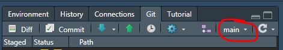

## Stage and Commit

### Create a Markdown file

### Stage

### Commit

## Push + Pull

### Push

### Pull

## Merge

### Pull Request

### Merge

## (Re)Sources

- [Link to Join Github](https://github.com/join)
- [How to Create a GitHub Account](https://www.wikihow.com/Create-an-Account-on-GitHub)
- [R Advisory Group Resources](https://doimspp.sharepoint.com/sites/nps-nrss-imdiv/SitePages/R-Adv.aspx) Monitors and manages the release of R, RStudio and Git in the NPS Software Center. The Advisory Group can help with installation and configuration issues.
- [Happy Git and GitHub for the useR](https://happygitwithr.com/index.html)
- [Version Control IMD Training](https://katemmiller.github.io/IMD_R_Training_Advanced/)
- [GitHub Git Cheat Sheet](https://training.github.com/downloads/github-git-cheat-sheet/)